# ECOG314 – Suggested project guidelines – A worked example using Wine dataset from UCI data repository

William Ampeh

September 12, 2016

## Demo on how to analyze a multivariate dataset from UCI ML data repository

### Reference materials

1. [This R Data Import Tutorial Is Everything You Need – R bloggers](http://blog.datacamp.com/r-data-import-tutorial/)
2. [Importing Data Into R - Part Two – R bloggers](http://www.r-bloggers.com/importing-data-into-r-part-two/)

## Data repositories

- [Financial Accounts of the United States](http://www.federalreserve.gov/datadownload/Choose.aspx?rel=Z.1)

[figure not shown]

- [DATA.GOV](https://www.data.gov/)
- [UCI Data Repository](http://archive.ics.uci.edu/ml/) – *Machine learning datasets*

[figure not shown]

## Financial Data repositories

- [Federal Reserve](http://www.federalreserve.gov/releases) – *few clicks required* financial_accounts_of_the_us.png
- [Data Market](https://datamarket.com/data/list/?q=provider:tsdl) *one of the user friendly Websites – few clicks required*
- [INFORUM](http://inforumweb.umd.edu/econdata/econdatacontents.html) – *requires Inforum’s database and regression package, G, to access that data*

## Big Data repositories

- [Data Science Central](http://www.datasciencecentral.com/profiles/blogs/big-data-sets-available-for-free)
- [Big data made simple](http://bigdata-madesimple.com/70-websites-to-get-large-data-repositories-for-free/)

[figure not shown]

- [Amazon Web Service (AWS)](https://aws.amazon.com/public-data-sets/)
- caesar0301/awesome-public-datasets

## Steps:

1. Visit the [UCI wine data repository](http://archive.ics.uci.edu/ml/datasets/Wine) for a detailed description, the data dictionary and maintainer of the data
   - results of a chemical analysis of the qualities of wines grown in the same region in Italy but derived from 3 different cultivars (*a plant variety that has been produced in cultivation by selective breeding*)
   - **14** columns (dimensions, attributes)
   - with **1st** column containing the cultivar of a wine sample (labelled 1, 2 or 3)
   - next **13** columns contain the concentrations of the 13 different chemicals in that sample
2. Setup your project workspace and *cd* into that direction (Session -> Set Working Directory -> Choose Directory (CNTRL+Shift+h)
3. Read dataset into R
   - *read.table(…)*
   - I always get a segment of the file first (for very large files)  
     read.table(“**my_some_datatable_name.txt**” header = TRUE, nrows = 25) # easier to work with smaller dataset

### Step 1 of N: Point browser to the UCI wine dataset repository

- [UCI ML wine dataset repository](http://archive.ics.uci.edu/ml/datasets/Wine)

### Step 2 of N: Clear workspace, and set and cd into working directory

```r
rm(list=ls())

# Set working directory and set Project-related global variables
setwd("C:/Users/William/Desktop/ECOG314/lecture_3")

# You do not have to, but if you need to share variable between different functions you can use
some_global_variable1 <<- 0                       # take note of the  <<-
some_global_variable2 <<- 0

max_steps <-  10

# alternatively you can use
assign("some_global_variable3", 0)

some_local_variable1 <- 0
```

### Step 3 of N: Read the multivariate dataset into R

#### Segments from the wine dataset:

```
 Line                       BEGIN DATA
  #   1   2    3    4    5    6   7   8    9   10   11   12   13   14
  1   1,14.23,1.71,2.43,15.6,127,2.8,3.06,.28,2.29,5.64,1.04,3.92,1065
  2   1,13.2,1.78,2.14,11.2,100,2.65,2.76,.26,1.28,4.38,1.05,3.4,1050
  3   1,13.16,2.36,2.67,18.6,101,2.8,3.24,.3,2.81,5.68,1.03,3.17,1185
  4   1,14.37,1.95,2.5,16.8,113,3.85,3.49,.24,2.18,7.8,.86,3.45,1480
...
 58   1,13.29,1.97,2.68,16.8,102,3,3.23,.31,1.66,6,1.07,2.84,1270
 59   1,13.72,1.43,2.5,16.7,108,3.4,3.67,.19,2.04,6.8,.89,2.87,1285
 60   2,12.37,.94,1.36,10.6,88,1.98,.57,.28,.42,1.95,1.05,1.82,520
 61   2,12.33,1.1,2.28,16,101,2.05,1.09,.63,.41,3.27,1.25,1.67,680
 62   2,12.64,1.36,2.02,16.8,100,2.02,1.41,.53,.62,5.75,.98,1.59,450
...
129   2,12.37,1.63,2.3,24.5,88,2.22,2.45,.4,1.9,2.12,.89,2.78,342
130   2,12.04,4.3,2.38,22,80,2.1,1.75,.42,1.35,2.6,.79,2.57,580
131   3,12.86,1.35,2.32,18,122,1.51,1.25,.21,.94,4.1,.76,1.29,630
132   3,12.88,2.99,2.4,20,104,1.3,1.22,.24,.83,5.4,.74,1.42,530
...
177   3,13.17,2.59,2.37,20,120,1.65,.68,.53,1.46,9.3,.6,1.62,840
178   3,14.13,4.1,2.74,24.5,96,2.05,.76,.56,1.35,9.2,.61,1.6,560
                                END DATA
```

#### Reading the data

- We use read.table() function to read in the data into R
- We use sep=“,” argument in read.table() to specify that columns are separated by commas.

```r
mysample <- 25     # Using nrows, even as a mild over-estimate, will help memory usage
                   # -1 => skip record #1, i.e., the HEADER in the file, resulting in 177 records (observations)

wine <- read.table(
         file = "http://archive.ics.uci.edu/ml/machine-learning-databases/wine/wine.data",  # filename at the UCI repository
       header = TRUE,        # filehas a header
          sep = ",",         # rows separated by commas
       nrow = mysample       # just the first n=25 rows + 1 header = 26
       )

#--
# check dimension of the data you have read -- data sanity check 1
dim(wine)
```

```
## [1] 25 14
```

```r
class(wine)
```

```
## [1] "data.frame"
```

```r
head(wine, n=5)
```

```
##   X1 X14.23 X1.71 X2.43 X15.6 X127 X2.8 X3.06 X.28 X2.29 X5.64 X1.04 X3.92 X1065
## 1  1  13.20  1.78  2.14  11.2  100 2.65  2.76 0.26  1.28  4.38  1.05  3.40  1050
## 2  1  13.16  2.36  2.67  18.6  101 2.80  3.24 0.30  2.81  5.68  1.03  3.17  1185
## 3  1  14.37  1.95  2.50  16.8  113 3.85  3.49 0.24  2.18  7.80  0.86  3.45  1480
## 4  1  13.24  2.59  2.87  21.0  118 2.80  2.69 0.39  1.82  4.32  1.04  2.93   735
## 5  1  14.20  1.76  2.45  15.2  112 3.27  3.39 0.34  1.97  6.75  1.05  2.85  1450
```

##### BIG DATA files, import and extract a random sample into R, then offload master file onto hard drive to free up memory

- Use *read.table(…)* function to read in the data into R
- Use *sample(…)* function to get a random sample from the raw data
- Use *saveRDS(…)* and *rm(…)* functions to saVE file to hard drive and remove BIG DATA file to free up memory
- For *Ubuntu* and *Linux* users, this can be done at the Operating System (OS) level
  - shuf -n 10 > small_wine_data.txt
  - Use nl wine_data.txt | shuf -n 10 to verify that the lines in file has been shuffled (randomized)

```r
# to take a random sample of 25 rows from the file

#
n <- sample(    x = c(1:178),      # range of rows
             size = 25,            # number of ranomly selected rows
          replace = FALSE          # sample WITHOUT replacement
      )

cat(sprintf("\nRows selected at random: %s\n", paste(n, collapse = ', ')))
```

```
##
## Rows selected at random: 112, 29, 156, 117, 75, 92, 134, 45, 60, 133, 105, 83, 2, 153, 107, 80, 143, 74, 140, 3, 56, 52, 8, 108, 121
```

```r
# Read the data from source
big_wine.df <- read.table(          # we know from above that the class of object returned by read.table is a data.frame (.df extension)
         file = "http://archive.ics.uci.edu/ml/machine-learning-databases/wine/wine.data",  # filename at the UCI repository
       header = TRUE,               # file has a header
          sep = ","                 # rows separated by commas.  NOTE:  We took out the comma after at the end of the line
       # nrow = mysample            # we are ready every line in the file
       )

# column names
colnames(big_wine.df) <- paste("v", 1:dim(big_wine.df)[2], sep="")    #  v1, v2, ....v13, v14
head(big_wine.df)
```

```
##   v1    v2   v3   v4   v5  v6   v7   v8   v9  v10  v11  v12  v13  v14
## 1  1 13.20 1.78 2.14 11.2 100 2.65 2.76 0.26 1.28 4.38 1.05 3.40 1050
## 2  1 13.16 2.36 2.67 18.6 101 2.80 3.24 0.30 2.81 5.68 1.03 3.17 1185
## 3  1 14.37 1.95 2.50 16.8 113 3.85 3.49 0.24 2.18 7.80 0.86 3.45 1480
## 4  1 13.24 2.59 2.87 21.0 118 2.80 2.69 0.39 1.82 4.32 1.04 2.93  735
## 5  1 14.20 1.76 2.45 15.2 112 3.27 3.39 0.34 1.97 6.75 1.05 2.85 1450
## 6  1 14.39 1.87 2.45 14.6  96 2.50 2.52 0.30 1.98 5.25 1.02 3.58 1290
```

```r
# check dimension of the data you have read -- data sanity check 1
dim(big_wine.df)
```

```
## [1] 177  14
```

```r
small_wine.df <- big_wine.df[n, ]   #every row specified by n.  That is 86, 153, 78, 43, 13, 18 .... this changes if you do not specify a seed

dim(small_wine.df)
```

```
## [1] 25 14
```

```r
small_wine.df                      # see that indeed we are not using the entire dataset
```

```
##     v1    v2   v3   v4   v5  v6   v7   v8   v9  v10   v11  v12  v13  v14
## 112  2 11.76 2.68 2.92 20.0 103 1.75 2.03 0.60 1.05  3.80 1.23 2.50  607
## 29   1 14.02 1.68 2.21 16.0  96 2.65 2.33 0.26 1.98  4.70 1.04 3.59 1035
## 156  3 13.84 4.12 2.38 19.5  89 1.80 0.83 0.48 1.56  9.01 0.57 1.64  480
## 117  2 12.42 1.61 2.19 22.5 108 2.00 2.09 0.34 1.61  2.06 1.06 2.96  345
## 75   2 11.66 1.88 1.92 16.0  97 1.61 1.57 0.34 1.15  3.80 1.23 2.14  428
## 92   2 12.69 1.53 2.26 20.7  80 1.38 1.46 0.58 1.62  3.05 0.96 2.06  495
## 134  3 12.51 1.24 2.25 17.5  85 2.00 0.58 0.60 1.25  5.45 0.75 1.51  650
## 45   1 14.21 4.04 2.44 18.9 111 2.85 2.65 0.30 1.25  5.24 0.87 3.33 1080
## 60   2 12.33 1.10 2.28 16.0 101 2.05 1.09 0.63 0.41  3.27 1.25 1.67  680
## 133  3 12.70 3.55 2.36 21.5 106 1.70 1.20 0.17 0.84  5.00 0.78 1.29  600
## 105  2 12.42 2.55 2.27 22.0  90 1.68 1.84 0.66 1.42  2.70 0.86 3.30  315
## 83   2 13.05 3.86 2.32 22.5  85 1.65 1.59 0.61 1.62  4.80 0.84 2.01  515
## 2    1 13.16 2.36 2.67 18.6 101 2.80 3.24 0.30 2.81  5.68 1.03 3.17 1185
## 153  3 13.23 3.30 2.28 18.5  98 1.80 0.83 0.61 1.87 10.52 0.56 1.51  675
## 107  2 12.72 1.75 2.28 22.5  84 1.38 1.76 0.48 1.63  3.30 0.88 2.42  488
## 80   2 12.00 0.92 2.00 19.0  86 2.42 2.26 0.30 1.43  2.50 1.38 3.12  278
## 143  3 13.62 4.95 2.35 20.0  92 2.00 0.80 0.47 1.02  4.40 0.91 2.05  550
## 74   2 11.96 1.09 2.30 21.0 101 3.38 2.14 0.13 1.65  3.21 0.99 3.13  886
## 140  3 12.93 2.81 2.70 21.0  96 1.54 0.50 0.53 0.75  4.60 0.77 2.31  600
## 3    1 14.37 1.95 2.50 16.8 113 3.85 3.49 0.24 2.18  7.80 0.86 3.45 1480
## 56   1 14.22 1.70 2.30 16.3 118 3.20 3.00 0.26 2.03  6.38 0.94 3.31  970
## 52   1 13.82 1.75 2.42 14.0 111 3.88 3.74 0.32 1.87  7.05 1.01 3.26 1190
## 8    1 14.83 1.64 2.17 14.0  97 2.80 2.98 0.29 1.98  5.20 1.08 2.85 1045
## 108  2 12.22 1.29 1.94 19.0  92 2.36 2.04 0.39 2.08  2.70 0.86 3.02  312
## 121  2 11.56 2.05 3.23 28.5 119 3.18 5.08 0.47 1.87  6.00 0.93 3.69  465
```

```r
#change the column names
colnames(small_wine.df) <- paste("v", 1:dim(small_wine.df)[2], sep="")    #  v1, v2, ....v13, v14
head(small_wine.df, n=5)
```

```
##     v1    v2   v3   v4   v5  v6   v7   v8   v9  v10  v11  v12  v13  v14
## 112  2 11.76 2.68 2.92 20.0 103 1.75 2.03 0.60 1.05 3.80 1.23 2.50  607
## 29   1 14.02 1.68 2.21 16.0  96 2.65 2.33 0.26 1.98 4.70 1.04 3.59 1035
## 156  3 13.84 4.12 2.38 19.5  89 1.80 0.83 0.48 1.56 9.01 0.57 1.64  480
## 117  2 12.42 1.61 2.19 22.5 108 2.00 2.09 0.34 1.61 2.06 1.06 2.96  345
## 75   2 11.66 1.88 1.92 16.0  97 1.61 1.57 0.34 1.15 3.80 1.23 2.14  428
```

### Step 4 of N: Handle Missing Values in data

After reading the dataset into R, do a summary on your data and deal with missing values in the data,  
See [Remove/Replace/Deal with NA entries](http://forums.psy.ed.ac.uk/R/P01582/essential-10/)

```r
#maybe
t(summary(small_wine.df))        # t(..) to transpose
```

```
##
##       v1 Min.   :1.00     1st Qu.:1.00     Median :2.00     Mean   :1.96     3rd Qu.:2.00     Max.   :3.00
##       v2 Min.   :11.56    1st Qu.:12.33    Median :12.72    Mean   :12.97    3rd Qu.:13.82    Max.   :14.83
##       v3 Min.   :0.920    1st Qu.:1.610    Median :1.880    Mean   :2.296    3rd Qu.:2.810    Max.   :4.950
##       v4 Min.   :1.920    1st Qu.:2.250    Median :2.300    Mean   :2.358    3rd Qu.:2.420    Max.   :3.230
##       v5 Min.   :14.00    1st Qu.:16.80    Median :19.00    Mean   :19.29    3rd Qu.:21.00    Max.   :28.50
##       v6 Min.   : 80.00   1st Qu.: 90.00   Median : 97.00   Mean   : 98.36   3rd Qu.:106.00   Max.   :119.00
##       v7 Min.   :1.380    1st Qu.:1.700    Median :2.000    Mean   :2.308    3rd Qu.:2.800    Max.   :3.880
##       v8 Min.   :0.500    1st Qu.:1.200    Median :2.030    Mean   :2.045    3rd Qu.:2.650    Max.   :5.080
##       v9 Min.   :0.1300   1st Qu.:0.3000   Median :0.3900   Mean   :0.4144   3rd Qu.:0.5800   Max.   :0.6600
##      v10 Min.   :0.410    1st Qu.:1.250    Median :1.620    Mean   :1.557    3rd Qu.:1.870    Max.   :2.810
##      v11 Min.   : 2.060   1st Qu.: 3.270   Median : 4.700   Mean   : 4.889   3rd Qu.: 5.680   Max.   :10.520
##      v12 Min.   :0.5600   1st Qu.:0.8600   Median :0.9300   Mean   :0.9456   3rd Qu.:1.0400   Max.   :1.3800
##      v13 Min.   :1.290    1st Qu.:2.050    Median :2.850    Mean   :2.612    3rd Qu.:3.260    Max.   :3.690
##      v14 Min.   : 278.0   1st Qu.: 480.0   Median : 600.0   Mean   : 694.2   3rd Qu.: 970.0   Max.   :1480.0
```

```r
# what about
apply(small_wine.df, 2, function(x) sum(is.na(x)))
```

```
##  v1  v2  v3  v4  v5  v6  v7  v8  v9 v10 v11 v12 v13 v14
##   0   0   0   0   0   0   0   0   0   0   0   0   0   0
```

```r
# what about big wine
t(summary(big_wine.df))
```

```
##
##       v1 Min.   :1.000    1st Qu.:1.000    Median :2.000    Mean   :1.944    3rd Qu.:3.000    Max.   :3.000
##       v2 Min.   :11.03    1st Qu.:12.36    Median :13.05    Mean   :12.99    3rd Qu.:13.67    Max.   :14.83
##       v3 Min.   :0.74     1st Qu.:1.60     Median :1.87     Mean   :2.34     3rd Qu.:3.10     Max.   :5.80
##       v4 Min.   :1.360    1st Qu.:2.210    Median :2.360    Mean   :2.366    3rd Qu.:2.560    Max.   :3.230
##       v5 Min.   :10.60    1st Qu.:17.20    Median :19.50    Mean   :19.52    3rd Qu.:21.50    Max.   :30.00
##       v6 Min.   : 70.00   1st Qu.: 88.00   Median : 98.00   Mean   : 99.59   3rd Qu.:107.00   Max.   :162.00
##       v7 Min.   :0.980    1st Qu.:1.740    Median :2.350    Mean   :2.292    3rd Qu.:2.800    Max.   :3.880
##       v8 Min.   :0.340    1st Qu.:1.200    Median :2.130    Mean   :2.023    3rd Qu.:2.860    Max.   :5.080
##       v9 Min.   :0.1300   1st Qu.:0.2700   Median :0.3400   Mean   :0.3623   3rd Qu.:0.4400   Max.   :0.6600
##      v10 Min.   :0.410    1st Qu.:1.250    Median :1.550    Mean   :1.587    3rd Qu.:1.950    Max.   :3.580
##      v11 Min.   : 1.280   1st Qu.: 3.210   Median : 4.680   Mean   : 5.055   3rd Qu.: 6.200   Max.   :13.000
##      v12 Min.   :0.480    1st Qu.:0.780    Median :0.960    Mean   :0.957    3rd Qu.:1.120    Max.   :1.710
##      v13 Min.   :1.270    1st Qu.:1.930    Median :2.780    Mean   :2.604    3rd Qu.:3.170    Max.   :4.000
##      v14 Min.   : 278.0   1st Qu.: 500.0   Median : 672.0   Mean   : 745.1   3rd Qu.: 985.0   Max.   :1680.0
```

```r
#Elegant way to report missing values in a data.frame:  http://stackoverflow.com/questions/8317231/elegant-way-to-report-missing-values-in-a-data-frame
sapply(big_wine.df, function(x) sum(is.na(x)))
```

```
##  v1  v2  v3  v4  v5  v6  v7  v8  v9 v10 v11 v12 v13 v14
##   0   0   0   0   0   0   0   0   0   0   0   0   0   0
```

### Step 4 of N: Plotting Multivariate Data

After reading the dataset into R, the next step is usually to plot of the resulting data  
See [Scatterplot matrices in R](https://www.r-bloggers.com/scatterplot-matrices-in-r/)

#### A Matrix Scatterplot

For multivariate data, one usually makes a matrix scatterplot, showing each pair of variables plotted against each other. The *scatterplotMatrix(…)* function is available in the car package. That is: *install.packages(“car”); library(car)*

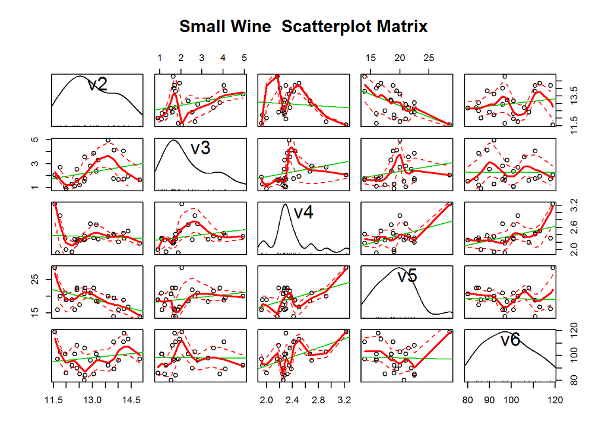

```r
#-
# Plot #1: A matrix scatterplot
windows()
scatterplotMatrix(small_wine.df[, 2:6],                  # exclude column 1, class label
                  main="Small Wine  Scatterplot Matrix"   # title of plot
                  )
```

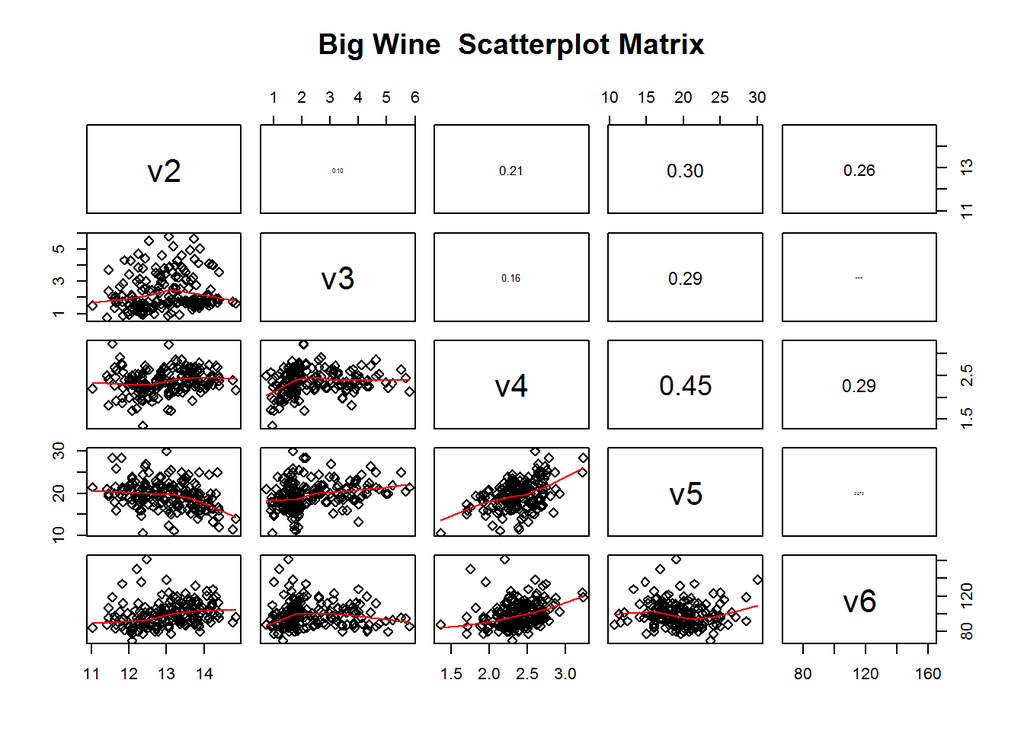

```r
#--
# panel.smooth function is built in.
# panel.cor puts correlation in upper panels, size proportional to correlation
panel.cor <- function(x, y, digits=2, prefix="", cex.cor, ...)
{
    usr <- par("usr"); on.exit(par(usr))
    par(usr = c(0, 1, 0, 1))
    r <- abs(cor(x, y))
    txt <- format(c(r, 0.123456789), digits=digits)[1]
    txt <- paste(prefix, txt, sep="")
    if(missing(cex.cor)) cex.cor <- 0.8/strwidth(txt)
    text(0.5, 0.5, txt, cex = cex.cor * r)
}

# Plot #2: same as above, but add loess smoother in lower and correlation in upper
windows()
pairs(big_wine.df[, 2:6],
      lower.panel=panel.smooth,             # lower portion of plot is the smooth plot
      upper.panel=panel.cor,                # uppper portion is a correlation plot
      pch=23,               # plot symbols, see http://www.statmethods.net/advgraphs/parameters.html
      main="Big Wine  Scatterplot Matrix",
      na.action = na.omit                   # causes cases with missing values in any of the variables to be omitted entirely.
      )
```

##### Scatterplot with data Points labelled by group

For example, the *pair plot* above, shows the 3rd column of the 4th row down is a scatterplot of V4 (x-axis) against V5 (y-axis). The figure shows a correlation of 0.45, that is a positive relationship between V4 and V5.

##### Zoom in on any interesting relationship with a plot

Use *plot(x= , y= )* or *qplot(x= , y= )*. I will use *ggplot(data= …)*

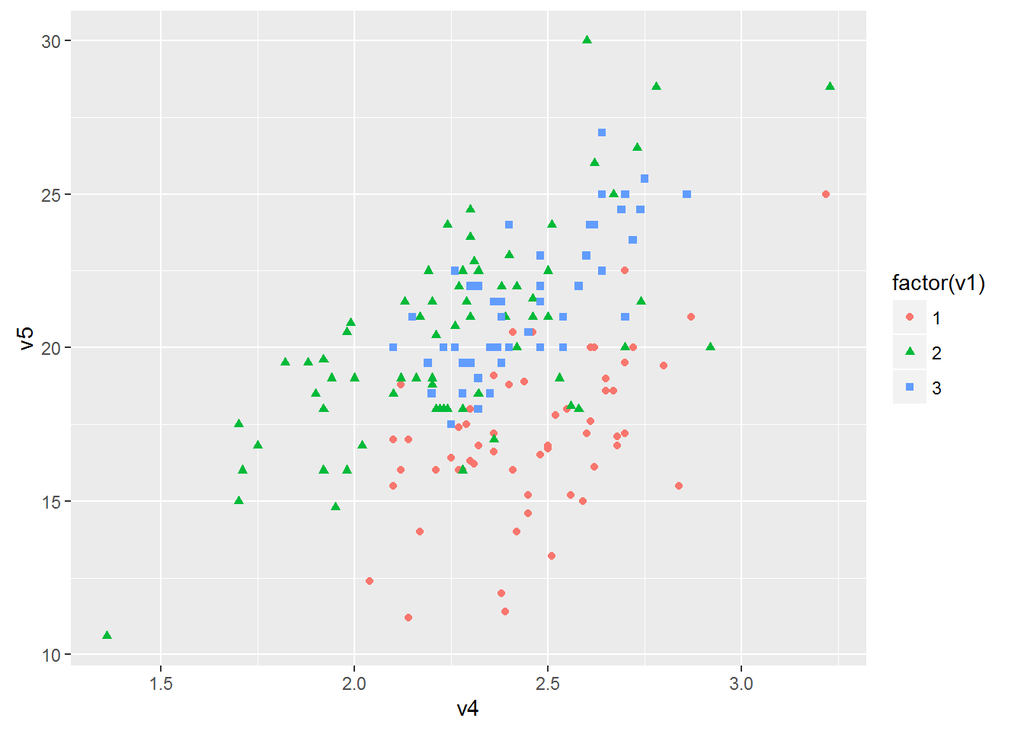

```r
# simplr plot
## define base for the graphs and store in object 'p'

v4_v5.plot <- ggplot(data = big_wine.df, aes(x = v4, y = v5, group=v1, color=factor(v1), shape=factor(v1)))

## just plotting points (a.k.a., scatterplot)
windows()
v4_v5.plot + geom_point() # +  #geom_line()     # simple spaghetti plot
```

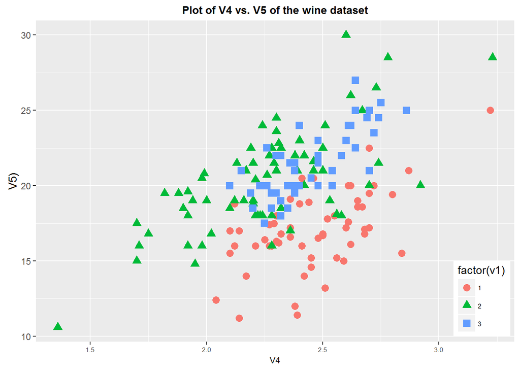

```r
#---
# A more elaborate plot
# setup plot
v4_v5.plot <- ggplot(                     # cool plotting package
  data=big_wine.df,                       # dataset in this case a data.frame
  aes(
         x = v4,                          # x-axis
         y = v5,                          # y-axis
     colour= factor(v1),                  # color to use for the points
     shape = factor(v1)
    )) +
  geom_point( size = 3)   +               # plot points only, with increased size
  xlab("V4")     +                        # x and y lables
  ylab("V5)")    +
  ggtitle("Plot of V4 vs. V5 of the wine dataset")



v4_v5.plot <- v4_v5.plot +
  theme(                       # the beauty of ggplot, you can add layers later
           plot.title = element_text(lineheight=1.2, face="bold", size=10.5 ),  #beautify title
           legend.position = c(1.01, 0.28), legend.justification=c(1,1),     #position the legend
      legend.position = "bottom", legend.justification=c(1,1),                 #position the legend
          legend.text = element_text(size=6.5),                                #format legend text
          axis.text.x = element_text(size=6.5),                                #format x-axis text
         axis.title.x = element_text(size = rel(0.75))                         #format x-axis title
  )

#--


#open a display window, else R will use RStudio's window
windows()

#-
# Add aesthetic mappings
#v4_v5.plot <- v4_v5.plot + geom_text(aes(colour = factor(v1), size=2))

# now display the plot
v4_v5.plot
```

#### Observation fom detailed plot

We can see from the plot of x=V4 versus y=V5 that

- wines from cultivar 1 seem to have lower values of V5 compared to the wines of cultivar 2 and 3
- wines from cultivar 2 seem to have lower values of V4 compared to the wines of cultivar 1

### A Profile Plot

[Good reference for profile plot](https://cran.r-project.org/web/packages/profileR/vignettes/jss_profileR.pdf)

[Useful functions for Multivariate data analysis](http://www.uni-regensburg.de/wirtschaftswissenschaften/vwl-tschernig/medien/programmieren-mit-r/pmr_tut_multivariatedataanalysis.r)

Another useful plot is a profile plot which plots the value of each of the variables for each of the samples to show the variation in each of the variables.

- Use the function *makeProfilePlot(…)* to make a profile plot. ++ Note: The *makeProfilePlot(…)* function requires the *RColorBrewer* library

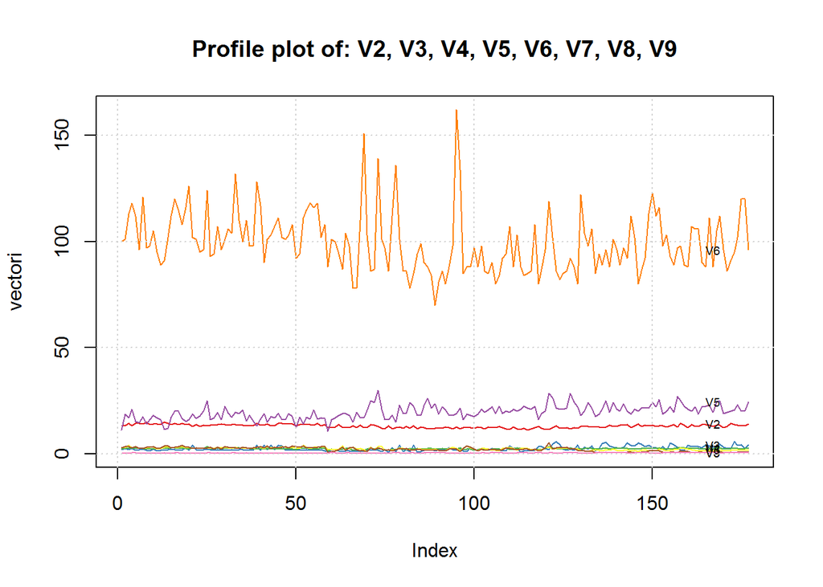

```r
source("helper_functions/pmr_tut_multivariatedataanalysis_edited_by_william.r")

#  Gives us access to the following functions:
# 1: makeProfilePlot

chem.names <- paste("V", 2:9, sep="")

mylist <- list(big_wine.df$v2, big_wine.df$v3, big_wine.df$v4, big_wine.df$v5,
               big_wine.df$v6, big_wine.df$v7, big_wine.df$v8, big_wine.df$v9)

#--
windows()

makeProfilePlot(mylist, chem.names,
                title=sprintf("Profile plot of: %s", paste(chem.names, collapse = ', '))
                )
grid()
```

#### Observation fom detailed plot

We can see from the profile plot that * the mean and standard deviation for V6 is quite a lot higher than that for the other variables.

### Calculating Summary Statistics for Multivariate Data

- For statistics on a dataset refer to the *Mosaic* package.
- Here we would calculate 2 summary statistics for each of the variables in the wine data set
- Use *sapply*

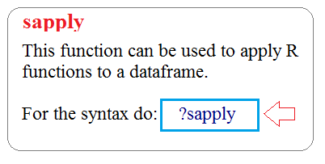

  - mean
  - standard deviation

```r
sapply(big_wine.df[, 2:9], mean)         #mean and std of 2nd to 9th variables
```

```
##         v2         v3         v4         v5         v6         v7         v8         v9
## 12.9936723  2.3398870  2.3661582 19.5169492 99.5875706  2.2922599  2.0234463  0.3623164
```

```r
sapply(big_wine.df[, 2:9], sd)
```

```
##         v2         v3         v4         v5         v6         v7         v8         v9
##  0.8088084  1.1193144  0.2750804  3.3360711 14.1740185  0.6264651  0.9986576  0.1246529
```

```r
# per sample type
group1_index = which(big_wine.df$v1 == 1); head(group1_index)   # get the index
```

```
## [1] 1 2 3 4 5 6
```

```r
group2_index = which(big_wine.df$v1 == 2); head(group2_index)
```

```
## [1] 59 60 61 62 63 64
```

```r
group3_index = which(big_wine.df$v1 == 3); head(group3_index)
```

```
## [1] 130 131 132 133 134 135
```

```r
sapply(big_wine.df[ group1_index, 2:9], mean)         #mean and std of 2nd to 9th variables
```

```
##          v2          v3          v4          v5          v6          v7          v8          v9
##  13.7363793   2.0158621   2.4560345  17.0620690 105.9827586   2.8408621   2.9810345   0.2901724
```

```r
sapply(big_wine.df[ group2_index, 2:9], mean)
```

```
##        v2        v3        v4        v5        v6        v7        v8        v9
## 12.278732  1.932676  2.244789 20.238028 94.549296  2.258873  2.080845  0.363662
```

```r
sapply(big_wine.df[ group3_index, 2:9], mean)
```

```
##         v2         v3         v4         v5         v6         v7         v8         v9
## 13.1537500  3.3337500  2.4370833 21.4166667 99.3125000  1.6787500  0.7814583  0.4475000
```

#### Observation

##### Means and Variances Per Group

```r
big_wine_groups.df <- t( big_wine.df %>% group_by(v1) %>% summarise_each(funs(mean, sd)) )  # transpose
colnames(big_wine_groups.df) <- c("Group_1", "Group_2", "Group_3")

#--
# exclude row 1, V1
big_wine_groups.df <- big_wine_groups.df[-(1), ]
head(big_wine_groups.df)
```

```
##            Group_1   Group_2   Group_3
## v2_mean  13.736379 12.278732 13.153750
## v3_mean   2.015862  1.932676  3.333750
## v4_mean   2.456034  2.244789  2.437083
## v5_mean  17.062069 20.238028 21.416667
## v6_mean 105.982759 94.549296 99.312500
## v7_mean   2.840862  2.258873  1.678750
```

```r
#show me rowsnames containing the word "mean"
# Use google: search for: "R show rownames that contain a word""
#http://stackoverflow.com/questions/13043928/selecting-rows-where-a-column-has-a-string-like-hsa-partial-string-match

index_of_row_name_contain_mean <- grep("_mean", rownames(big_wine_groups.df))      #=>  2  3  4  5  6  7  8  9 10 11 12 13 14

#-
# Now show the rows containing the word "mean"
group.means <- big_wine_groups.df[index_of_row_name_contain_mean, ]
group.means
```

```
##               Group_1    Group_2     Group_3
## v2_mean    13.7363793  12.278732  13.1537500
## v3_mean     2.0158621   1.932676   3.3337500
## v4_mean     2.4560345   2.244789   2.4370833
## v5_mean    17.0620690  20.238028  21.4166667
## v6_mean   105.9827586  94.549296  99.3125000
## v7_mean     2.8408621   2.258873   1.6787500
## v8_mean     2.9810345   2.080845   0.7814583
## v9_mean     0.2901724   0.363662   0.4475000
## v10_mean    1.8925862   1.630282   1.1535417
## v11_mean    5.5263793   3.086620   7.3962500
## v12_mean    1.0624138   1.056282   0.6827083
## v13_mean    3.1446552   2.785352   1.6835417
## v14_mean 1116.5862069 519.507042 629.8958333
```

```r
#---
# do the same for variance
group.variance <- big_wine_groups.df[-c(index_of_row_name_contain_mean), ]
group.variance
```

```
##             Group_1     Group_2     Group_3
## v2_sd    0.46163211   0.5379642   0.5302413
## v3_sd    0.69340005   1.0155687   1.0879057
## v4_sd    0.22912449   0.3154673   0.1846902
## v5_sd    2.56137488   3.3497704   2.2581609
## v6_sd   10.22465438  16.7534975  10.8904726
## v7_sd    0.34187966   0.5453611   0.3569709
## v8_sd    0.40083111   0.7057008   0.2935041
## v9_sd    0.07064841   0.1239613   0.1241396
## v10_sd   0.41241931   0.6020678   0.4088359
## v11_sd   1.24930114   0.9249293   2.3109421
## v12_sd   0.11746310   0.2029368   0.1144411
## v13_sd   0.34550353   0.4965735   0.2721114
## v14_sd 223.35276437 157.2112204 115.0970432
```

### Toy dataset

Most times it is better doing the exploratory work using a smaller dataset and then use the code written on your big dataset. An example is shown below:

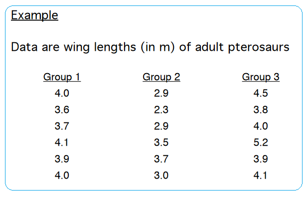

```r
toy.data <- read.table(header = TRUE, text = "
Group_1 Group_2 Group_3
4.0 2.9 4.5
3.6 2.3 3.8
3.7 2.9 4.0
4.1 3.5 5.2
3.9 3.7 3.9
4.0 3.0 4.1
")

toy.data                                        #show the data
```

```
##   Group_1 Group_2 Group_3
## 1     4.0     2.9     4.5
## 2     3.6     2.3     3.8
## 3     3.7     2.9     4.0
## 4     4.1     3.5     5.2
## 5     3.9     3.7     3.9
## 6     4.0     3.0     4.1
```

```r
#--
toy.df <<- melt(toy.data)
```

```
## Using  as id variables
```

```r
colnames(toy.df) <- c("v1", "v2")
toy.df
```

```
##         v1  v2
## 1  Group_1 4.0
## 2  Group_1 3.6
## 3  Group_1 3.7
## 4  Group_1 4.1
## 5  Group_1 3.9
## 6  Group_1 4.0
## 7  Group_2 2.9
## 8  Group_2 2.3
## 9  Group_2 2.9
## 10 Group_2 3.5
## 11 Group_2 3.7
## 12 Group_2 3.0
## 13 Group_3 4.5
## 14 Group_3 3.8
## 15 Group_3 4.0
## 16 Group_3 5.2
## 17 Group_3 3.9
## 18 Group_3 4.1
```

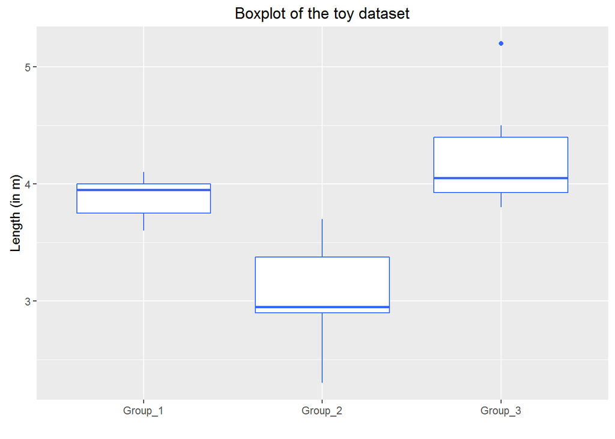

````r
#--
#```

##### Boxplot
#```{r}
#  do a boxplot
p <- ggplot(toy.df, aes(v1, v2))
p <- p + geom_boxplot(fill = "white", colour = "#3366FF") +
     ylab("Length (in m)") + xlab("") +
     ggtitle("Boxplot of the toy dataset")
p  # display plot
````

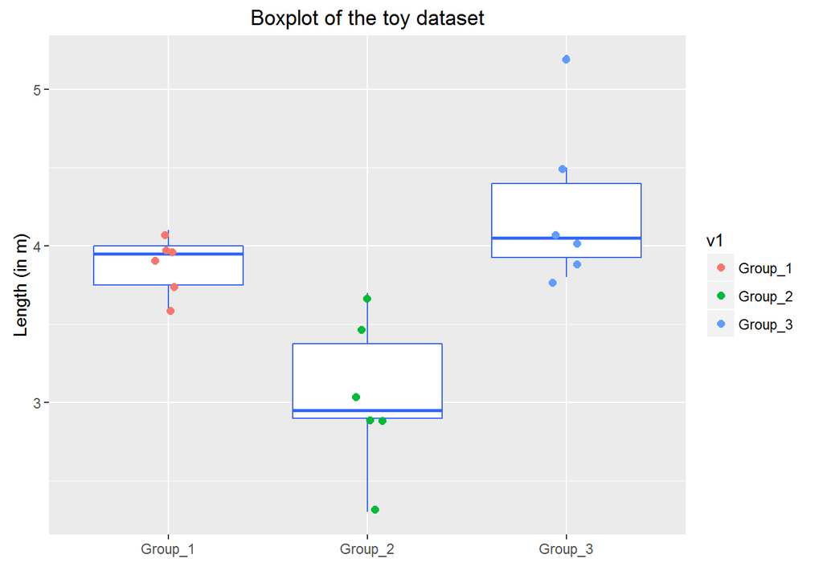

```r
#ADD POINTS IF YOU WISH
p <- p + geom_jitter(width = 0.2, aes(colour = v1), size=2)   #add points
p   # display plot
```

```r
# # beautify plot
# p <- p + theme(
#          legend.position = c(1.01, 0.19), legend.justification=c(1,1),     #position the legend
#         legend.position = "bottom", legend.justification=c(1,1),           #position the legend
#           legend.text = element_text(size=6.5))                           #format legend text
#
# #plot
# windows()
# p
```

##### Descriptive Statistics

```r
#--
# Get N
N.dim = dim( toy.df )
N <- ( N.dim[1] * N.dim[2] ) - N.dim[1]        # could have simply said N.dim[1], but setting program up for big_wine.df
N
```

```
## [1] 18
```

```r
# group counts
n <- toy.df %>% group_by(v1) %>% summarise_each(funs(length))
n                                               # data frame [3 x 14]
```

```
## Source: local data frame [3 x 2]
##
##        v1    v2
##    (fctr) (int)
## 1 Group_1     6
## 2 Group_2     6
## 3 Group_3     6
```

```r
#-
K = 3                                           # K = number of groups
#--
#  Note
# mean(big_wine.df) returns column means
# mean( as.matrix(big_wine.df ) ) # one value.

x_2bar <-  mean(as.matrix(toy.df[, -c(1)] ))
x_2bar
```

```
## [1] 3.727778
```

```r
#-
toy.table <- toy.df %>% group_by(v1) %>% summarise_each(funs(length, mean, sd, min, max))
toy.table$stderr     <- toy.table$sd / sqrt(toy.table$length)
toy.table$E          <- qnorm(.975)*toy.table$stderr        # margin of error  95% CI
toy.table$lowerbound <- toy.table$mean - toy.table$E
toy.table$upperbound <- toy.table$mean + toy.table$E

descriptive.stats <- data.frame(
           Groups = c(1:3),
                N = c(toy.table$length),
             Mean = c(toy.table$mean),
  "Std Deviation" = c(toy.table$sd),
      "Std Error" = c(toy.table$stderr),
 "CI_Lower Bound" = c(toy.table$lowerbound),
 "CI_Upper Bound" = c(toy.table$upperbound),
        "Minimum" = c(toy.table$min),
       "Maximum" = c(toy.table$max)
 )

#--
#show table
descriptive.stats
```

```
##   Groups N     Mean Std.Deviation  Std.Error CI_Lower.Bound CI_Upper.Bound Minimum Maximum
## 1      1 6 3.883333     0.1940790 0.07923243       3.728041       4.038626     3.6     4.1
## 2      2 6 3.050000     0.4969909 0.20289570       2.652332       3.447668     2.3     3.7
## 3      3 6 4.250000     0.5244044 0.21408721       3.830397       4.669603     3.8     5.2
```

### We will extend this to out wine dataset in out next lecture